# Python Language Basics

This notebook introduces some Python language basics. It is designed for a code-along during the workshop. Some code blocks are deliberately incomplete or have bugs included.

To execute code: Place your cursor in the cell, then hit SHIFT + ENTER

When writing computer code, there are *rules* and there are *conventions* (adapted from David Dempsey's [Python for Geoscientists](https://github.com/ddempsey/python_for_geoscientists) course)

- If you break a *rule*, the code will not work.
- If you break a *convention*, someone, somewhere puts a mark against your name in a book. At the end of times, there will be a final accounting.

Some Python rules:

- *Syntax* - we have very precise expectations about how you write computer code. If you type an opening a bracket, you must close it again later. Some lines must be terminated by a colon, - if you omit this, the code will not work. *Learning syntax for a new code is very pedantic and a total pain.* But you have to do it anyway, and at least Python returns readable error messages to help you understand your missteps...
- *Indentation* - Python reads indentation (not all languages do) and your code will not work if it is not correctly indented.

Some Python conventions:

- *Commenting* - it is helpful for the poor soul who has to read your poorly written Python (sometimes that is you, weeks or months later) if you have included little 'sign-posts' in the code, articulating what you are doing. These are called comments. They begin with a # symbol, after which you can write whatever you like and it will not be executed as a command.
- *Sensible variable names* - a word or words relating to the thing the variable represents but not too long. For example, if a variable contains the mean temperature, then Tmean is a sensible variable name, where as the_mean_temperature_of_the_profile or a1 are not sensible variable names.
- *Layout* - Although the computer reads Python line-by-line, using a vertical layout improves the human readability and your ability to comment code. Headings and the liberal use of whitespace improves readbility.
- *Structure* - Python files and projects have a standard structure that improves redabality. The structure of files vary, but all files should start with an explanation of what they do and all packages/modules should be imported at the top. For the advanced folks, more on Python project structure can be found [here](https://docs.python-guide.org/writing/structure/).

Units are a common source of error. Approches to managing this include:

- Include units in the variable names (my preferred) `Tmean_degC = 300`
- Include in-line comments on units and conversions used (good, but can be lost information) `Tmean = 300 # mean temp in degC`
- Consider tools like [Pint](https://pint.readthedocs.io/en/stable/) to manage units, if it is a large problem (good, but assumes everyone knows how to use pint)

## Python Packages

```python
# Import packages

''' Good practice:
Import all libraries/packages used at the top of the document'''

import matplotlib.pyplot as plt # foundation module for plotting
import numpy as np # for array based programming and advanced math
import math # for basic mathematical methods
import pandas as pd # for spreadsheet-like methods + more
import matplotlib.pyplot as plt # foundation module for plotting
import seaborn as sns # for advanced plotting methods
import matplotlib.dates as mdates # for formatting datetime in plot axis

''' Good practice:
Packages have standard short names.
Using the standard name improves readability.
Look at the docs if you are unsure what the standard name is.
For example, https://matplotlib.org/3.5.3/api/_as_gen/matplotlib.pyplot.html) ''';
```

```python
import antigravity

# installing a package can launch code
# be careful what you install!
```

## Python Language Basics

```python
print('hello world')
```

```
hello world
```

```python
# variable
# the string 'hello world' has been assigned to the variable x

x = 'hello world'

print(x)
print(len(x))
```

```
hello world
11
```

```python
# Types: string, integer, float (more on slide)
# Python is a dynamic typed language, checking type (variable state)

print(type(x))
```

```
<class 'str'>
```

Data structures and the many forms of list https://docs.python.org/3/tutorial/datastructures.html#

```python
# Lists and array (numpy)

my_list = [1,2,3,4]
print(my_list)
print(type(my_list))

my_array = np.array([1,2,3,4])
print(my_array)
print(type(my_array))
```

```
[1, 2, 3, 4]
<class 'list'>
[1 2 3 4]
<class 'numpy.ndarray'>
```

```python
array_of_10s = np.array([10,10,10,10])
array_of_5s = np.array([5,5,5,5])

new_array = array_of_5s + array_of_10s

print(new_array)

# array-based programming
```

```
[15 15 15 15]
```

```python
list_of_10s = [10,10,10,10]
list_of_5s = [5,5,5,5]

new_list = list_of_5s + list_of_10s

print(new_list)
```

```
[5, 5, 5, 5, 10, 10, 10, 10]
```

```python
# Basics: Complex lists and arrays

complex_list = ['harry', 1, 9.5, [2,3,4]]
print(complex_list)

complex_array = np.array(['harry', 1, 9.5,[2,3,4]],dtype=object)
print(complex_array, complex_array.shape)

nD_array = np.array([[4,5,6],[1,2,3]])
print(nD_array, nD_array.shape)

# shape tells us the number of elements in each dimension
```

```
['harry', 1, 9.5, [2, 3, 4]]
['harry' 1 9.5 list([2, 3, 4])] (4,)
[[4 5 6]
 [1 2 3]] (2, 3)
```

```python
# tuple - a fixed collection of objects or variables

my_tuple = (3, 5, 7)

my_object = [9.1,9.2,9.3]

complex_tuple = (3, 5, 7, ['d','wow',3.2], 'fish', my_object)

print(type(complex_tuple))

# Lists vs tuples
# Tuples are more memory efficient than lists
# Generally, people expect lists to contain one type while it is more acceptable to mix types in a tuple
```

```
<class 'tuple'>
```

```python
# indexing (lists, tuples and arrays)

print(complex_tuple[1])
print(complex_tuple[3][1])

print(complex_tuple[5][-1]) # get 9.3 out of complex_tuple
print(complex_tuple[5][2]) # get 9.3 out of complex_tuple

# note how python starts counting at zero, so the first element = 0
```

```
5
wow
9.3
9.3
```

```python
# dictionary - a value is mapped to a key
colors = {
    'blue': '#36648B', # nice low-saturation blue
    'brown': '#8B5D36', # complementary color to the blue
}

print(colors)

print(type(colors))

print(colors['blue'])

colors['blue'] = 'another blue'
print(colors['blue'])
```

```
{'blue': '#36648B', 'brown': '#8B5D36'}
<class 'dict'>
#36648B
another blue
```

Colors in Python:

- Hex colors https://www.color-hex.com/
- Named colors https://matplotlib.org/stable/gallery/color/named_colors.html
- Colormaps https://matplotlib.org/stable/tutorials/colors/colormaps.html

Beware the impact of color on your analysis! https://hess.copernicus.org/articles/25/4549/2021/

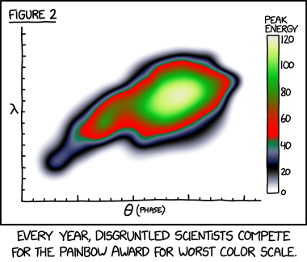

```python
from IPython import display
display.Image("https://imgs.xkcd.com/comics/painbow_award.png")
```

## Python as Calculator

```python
radius_m = 3
area_m2 = math.pi * radius_m**2

print(area_m2)
```

```
28.274333882308138
```

Estimating well injectivity using field operational data:

$$ I I=\frac{Q}{P_{H}+W H P-P_{F}-P_{F Z}} $$

where $Q$ Flow rate (t/hr), $P_{H}$ is hydrostatic pressure inside the well (bara), $WHP$ is wellhead pressure (bara), $P_{F}$ is the pressure of frictional losses (bara), and $P_{F Z}$ is the reservoir pressure at the feedzone or pivot point (bara).

*(Siega et al. (2014) Quantifying the effect of temperature on well injectivity, New Zealand Geothermal Workshop)*

Python uses Latex for formatting mathematical expressions https://www.overleaf.com/learn/latex/Mathematical_expressions

```python
# Variable names:
# Use common abbreviations or write it out
# Do not just use equation terms (Q, Ph, WHP) unless they are universal and defined somewhere in your file

flow_rate_tph = 400
hydrostatic_pressure_bara = 115
wellhead_pressure_bara = 1
friction_loss_bara = 9.7
feedzone_pressure_bara = 84

ii_tphrpbar = flow_rate_tph / (hydrostatic_pressure_bara + wellhead_pressure_bara - friction_loss_bara - feedzone_pressure_bara)

print(ii_tphrpbar)
```

```
17.937219730941706
```

```python
# Using for loops to calculate value for multiple values - iterate over one list

flow_rates_tph = [400, 300, 200, 100]

varied_rate_ii_tphrpbar = []

for rate in flow_rates_tph:
    ii = rate / (hydrostatic_pressure_bara + wellhead_pressure_bara - friction_loss_bara - feedzone_pressure_bara)
    varied_rate_ii_tphrpbar.append(ii)

print(varied_rate_ii_tphrpbar)
```

```
[17.937219730941706, 13.45291479820628, 8.968609865470853, 4.4843049327354265]
```

## Algorithm building: Logical operators and flow control

Tests that return True or False

### Boolean operators

- And
- Or
- Not

### Comparison operators

- == Equal to
- != Not equal to
- < Less than
- > Greater Than
- <= Less than or Equal to
- >= Greater than or Equal to

### "if" statements

- if
- elif
- else

### 'for' loop

- pass in a list or array that is iterated over

Refer to [this link](https://www.pythoncheatsheet.org/cheatsheet/control-flow) for other options and various examples.

```python
# Basics: "for loop" and whitespace
for n in [1,2,3,4,5]:
    print(n + 10)
```

```
11
12
13
14
15
```

```python
# Using for loops to calculate value for multiple values - iterate over many lists

flow_rates_tph = [400, 300, 200, 100]
wellhead_pressures_bara = [10, 8, 5, 1]

varied_rate_and_whp_ii_tphrpbar = []

for rate, whp in zip(flow_rates_tph, wellhead_pressures_bara):
    ii = rate / (hydrostatic_pressure_bara + whp - friction_loss_bara - feedzone_pressure_bara)
    varied_rate_and_whp_ii_tphrpbar.append(ii)

print(varied_rate_and_whp_ii_tphrpbar)
```

```
[12.779552715654953, 10.238907849829353, 7.604562737642587, 4.4843049327354265]
```

```python
# Using if statements to dictate behavior

flow_rates_tph = [400, 300, 200, 100]
wellhead_pressures_bara = [10, 8, 5, 1]

for rate, whp in zip(flow_rates_tph, wellhead_pressures_bara):
    ii = rate / (hydrostatic_pressure_bara + whp - friction_loss_bara - feedzone_pressure_bara)
    if ii > 10:
        print('Great well!')
    else:
        print(':-(')
```

```
Great well!
Great well!
:-(
:-(
```

## Plotting

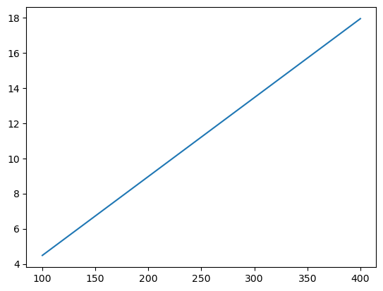

```python
# Simple

plt.plot(flow_rates_tph, varied_rate_ii_tphrpbar)
```

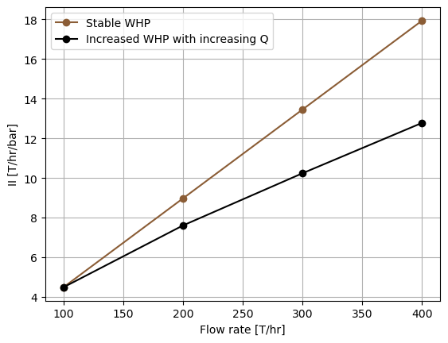

```python
# More flexibility: the axs method
# when googling, use "matplotlib axs" to get the correct documentation

fig, ax = plt.subplots(1,1)

# the method plt.subplots() returns two things
# one we have called figure (f or fig) and this is analogous to a page in your book
# the other is the axis (one or many ax) which is analogous to the plot you draw on the that page

ax.plot(
    flow_rates_tph,
    varied_rate_ii_tphrpbar,
    color = colors['brown'],
    marker = 'o',
    label = 'Stable WHP'
    )

ax.plot(
    flow_rates_tph,
    varied_rate_and_whp_ii_tphrpbar,
    color = 'k',
    marker = 'o',
    label = 'Increased WHP with increasing Q'
    )

ax.set_ylabel('II [T/hr/bar]')
ax.set_xlabel('Flow rate [T/hr]')
ax.legend()
ax.grid()

# https://github.com/ICWallis/tutorial-publication-ready-figures
```

## Functions

```python
# Functions = re-useable tools

def circle_area(radius):
    '''Calculate the area of a circle from the radius'''

    area = math.pi * radius**2

    return area

a = circle_area(5)
print(a)
```

```
78.53981633974483
```

```python
#
# Function
#

def ii_from_operational_conditions(Q,Ph,WHP,Pf,Pfz):
    '''Calculate injectivity using field operational data

    For usage and case study, refer to Siega et al. (2014)
    Quantifying the effect of temperature on well injectivity,
    New Zealand Geothermal Workshop

        Args:
            Q (float): flow rate - t/hr
            Ph (float): hydrostatic pressure inside the well - bara
            WHP (float): wellhead pressure - bara
            Pf (float): pressure due to friction - bara
            Pfz (float): reservoir pressure at the feedzone or pivot point - bara

        Returns:
            injectivity - T/hr/bar
    '''

    ii = Q / (Ph + WHP - Pf - Pfz)

    return ii

#
# Usage
#

# Input parameters for well WJ-13
Q_tph = 400 # average for June
Ph_bara = 115 # calculated using depth to feedzone and average injection temperature
WHP_bara = 1 # average for June
Pf_bara = 9.7 # calculated by finding the root of the Colebrook equation
Pfz_bara = 84 # from the reservoir pressure correlation

WJ13_June_ii_tphrpbar = ii_from_operational_conditions(Q_tph, Ph_bara, WHP_bara, Pf_bara, Pfz_bara)

print(round(WJ13_June_ii_tphrpbar,2))


# Functions can be placed in a file that is imported at the start
# This reduces the code you are looking at
# and enables you to focus on the science, rather than the code
```

```
17.94
```

```python
df = pd.read_excel(r'1_Introduction__Case_study_data.xlsx', sheet_name='Sheet1')
df
```

|  | Well | Date | Q_tph | Ph_bara | WHP_bara | Pf_bara | Pfz_bara |
| --- | --- | --- | --- | --- | --- | --- | --- |
| 0 | W-1 | 2022-01-01 | 400 | 115 | 1.0 | 9.70 | 84 |
| 1 | W-1 | 2022-02-01 | 400 | 115 | 1.5 | 9.70 | 84 |
| 2 | W-1 | 2022-03-01 | 400 | 115 | 2.0 | 9.70 | 84 |
| 3 | W-1 | 2022-04-01 | 400 | 115 | 2.8 | 9.70 | 84 |
| 4 | W-2 | 2022-01-01 | 200 | 100 | 8.0 | 9.68 | 70 |
| 5 | W-2 | 2022-02-01 | 200 | 100 | 5.0 | 9.68 | 70 |
| 6 | W-2 | 2022-03-01 | 200 | 100 | 2.0 | 9.68 | 70 |
| 7 | W-2 | 2022-04-01 | 200 | 100 | 1.0 | 9.68 | 70 |

```python
df.info()
```

```
<class 'pandas.core.frame.DataFrame'>
RangeIndex: 8 entries, 0 to 7
Data columns (total 7 columns):
 #   Column    Non-Null Count  Dtype
---  ------    --------------  -----
 0   Well      8 non-null      object
 1   Date      8 non-null      datetime64[ns]
 2   Q_tph     8 non-null      int64
 3   Ph_bara   8 non-null      int64
 4   WHP_bara  8 non-null      float64
 5   Pf_bara   8 non-null      float64
 6   Pfz_bara  8 non-null      int64
dtypes: datetime64[ns](1), float64(2), int64(3), object(1)
memory usage: 576.0+ bytes
```

```python
df['ii_tphrpbar'] = ii_from_operational_conditions(df.Q_tph, df.Ph_bara, df.WHP_bara, df.Pf_bara, df.Pfz_bara)
df
```

|  | Well | Date | Q_tph | Ph_bara | WHP_bara | Pf_bara | Pfz_bara | ii_tphrpbar |
| --- | --- | --- | --- | --- | --- | --- | --- | --- |
| 0 | W-1 | 2022-01-01 | 400 | 115 | 1.0 | 9.70 | 84 | 17.937220 |
| 1 | W-1 | 2022-02-01 | 400 | 115 | 1.5 | 9.70 | 84 | 17.543860 |
| 2 | W-1 | 2022-03-01 | 400 | 115 | 2.0 | 9.70 | 84 | 17.167382 |
| 3 | W-1 | 2022-04-01 | 400 | 115 | 2.8 | 9.70 | 84 | 16.597510 |
| 4 | W-2 | 2022-01-01 | 200 | 100 | 8.0 | 9.68 | 70 | 7.062147 |
| 5 | W-2 | 2022-02-01 | 200 | 100 | 5.0 | 9.68 | 70 | 7.898894 |
| 6 | W-2 | 2022-03-01 | 200 | 100 | 2.0 | 9.68 | 70 | 8.960573 |
| 7 | W-2 | 2022-04-01 | 200 | 100 | 1.0 | 9.68 | 70 | 9.380863 |

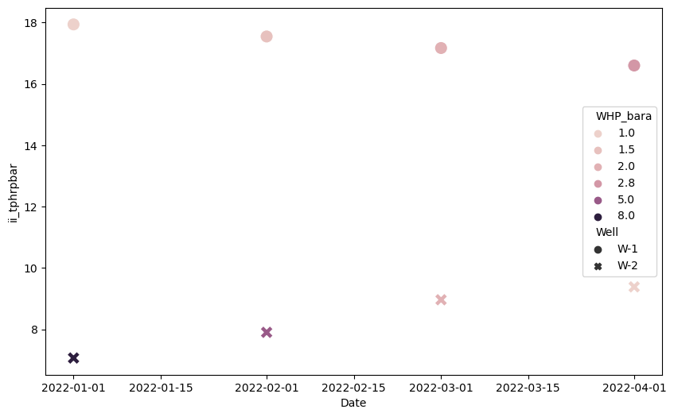

```python
# Advanced plot for data analysis

fig, ax = plt.subplots(1,1,figsize=(10,6))

# https://seaborn.pydata.org/generated/seaborn.scatterplot.html

sns.scatterplot(
    x='Date', # Pandas column name for x data
    y='ii_tphrpbar', # Pandas column name for y data
    data=df, # Pandas dataframe name
    ax=ax, # name of the axis that the seaborn plot goes in
    s=140, # marker size
    hue='WHP_bara', # marker colour
    style='Well', # marker style
)

#plt.savefig('Case_study_plot1.png',facecolor='w')
```

[output not shown]

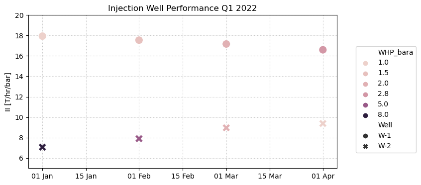

```python
# Building on the above code to make a nice version for a report/publication

# Make empty plot
fig, ax = plt.subplots(1,1,figsize=(8,4))

# Add data to plot
sns.scatterplot(
    x='Date', # Pandas column name for x data
    y='ii_tphrpbar', # Pandas column name for y data
    data=df, # Pandas dataframe name
    ax=ax, # name of the axis that the seaborn plot goes in
    s=140, # marker size
    style='Well', # marker style
    hue='WHP_bara', # marker colour
    #palette='cividis',
    #size='Q_tph',
    #sizes=(140, 200)
    zorder=10 # places markers in front of grid
)

# Seaborn color pallets https://seaborn.pydata.org/tutorial/color_palettes.html

# Format axis
ax.set_ylim(5,20)

ax.xaxis.set_major_formatter(mdates.DateFormatter("%d %b"))

ax.set_xlabel('') # Replaces auto date label with nothing

ax.set_ylabel('II [T/hr/bar]')

# Place legend outside the plot area
ax.legend(
    loc='center left',
    bbox_to_anchor=(1.05, 0.45),
    ncol=1,
)

# Add title
plt.title('Injection Well Performance Q1 2022')

# Add grid
ax.grid(linestyle=':', alpha=0.8)

# Export figure
'''
plt.savefig(
    'Case_study_plot2.png',
    dpi=400,
    facecolor='w',
    bbox_inches='tight'
    )'''
```

## Sub-select data using comparison operator

```python
df.columns
```

```
Index(['Well', 'Date', 'Q_tph', 'Ph_bara', 'WHP_bara', 'Pf_bara', 'Pfz_bara',
       'ii_tphrpbar'],
      dtype='object')
```

```python
df
```

|  | Well | Date | Q_tph | Ph_bara | WHP_bara | Pf_bara | Pfz_bara | ii_tphrpbar |
| --- | --- | --- | --- | --- | --- | --- | --- | --- |
| 0 | W-1 | 2022-01-01 | 400 | 115 | 1.0 | 9.70 | 84 | 17.937220 |
| 1 | W-1 | 2022-02-01 | 400 | 115 | 1.5 | 9.70 | 84 | 17.543860 |
| 2 | W-1 | 2022-03-01 | 400 | 115 | 2.0 | 9.70 | 84 | 17.167382 |
| 3 | W-1 | 2022-04-01 | 400 | 115 | 2.8 | 9.70 | 84 | 16.597510 |
| 4 | W-2 | 2022-01-01 | 200 | 100 | 8.0 | 9.68 | 70 | 7.062147 |
| 5 | W-2 | 2022-02-01 | 200 | 100 | 5.0 | 9.68 | 70 | 7.898894 |
| 6 | W-2 | 2022-03-01 | 200 | 100 | 2.0 | 9.68 | 70 | 8.960573 |
| 7 | W-2 | 2022-04-01 | 200 | 100 | 1.0 | 9.68 | 70 | 9.380863 |

```python
# using reassignment - take care of notebook order!
df = df[df.Well == 'W-1']
```

```python
df
```

|  | Well | Date | Q_tph | Ph_bara | WHP_bara | Pf_bara | Pfz_bara | ii_tphrpbar |
| --- | --- | --- | --- | --- | --- | --- | --- | --- |
| 0 | W-1 | 2022-01-01 | 400 | 115 | 1.0 | 9.7 | 84 | 17.937220 |
| 1 | W-1 | 2022-02-01 | 400 | 115 | 1.5 | 9.7 | 84 | 17.543860 |
| 2 | W-1 | 2022-03-01 | 400 | 115 | 2.0 | 9.7 | 84 | 17.167382 |
| 3 | W-1 | 2022-04-01 | 400 | 115 | 2.8 | 9.7 | 84 | 16.597510 |

### Where to from here?

*The best way forward is to learn by doing!*

I most commonly use python to...

Document methods and analysis in Jupyter notebooks:

- Methods are displayed in sequence
- Can combine notes, equations, views on the data and plots in an easily read format
- Can be exported to html so non-coding folks can read them

Automate tasks:

- Especially useful for repetitive data processing tasks
- [Automate the Boring Stuff](https://automatetheboringstuff.com/) is a great book for getting started with Python and automation

Handle large datasets, do complex calculations, make interactive graphics, and more!

**Learn more Python skills** using on-line resources:

- A [list of useful resources](https://mharty3.github.io/resources/) for geoscientists learning python has been put together by Michael Harty
- [Practical Python](https://dabeaz-course.github.io/practical-python/Notes/Contents.html) great course if you can survive stock tickers. Self driven and comprehensive.
- David Dempsey's [Python for Geoscientists](https://github.com/ddempsey/python_for_geoscientists) specific to geosciences. Designed to be classroom taught, but chock-full of useful examples.
- [Plotting with Python](https://github.com/ICWallis/tutorial-publication-ready-figures) for basic to advanced plotting with matplotlib. Designed to be classroom taught, but see solutions and recipes folders for code examples.
- [Software carpentry](https://software-carpentry.org/lessons/) a wide range of learning resources
- [EdX course](https://www.edx.org/course/introduction-computer-science-harvardx-cs50x)

**Find your community** and join [Software Underground](https://softwareunderground.org/) to connect with people who do computers + subsurface

- Active slack community where people help each other (note that they are currently moving to a new platform because of $$)
- Annual virtual conference with lots of free training opportunities
- [SWUG YouTube channel](https://www.youtube.com/c/softwareunderground), with loads of subsurface-relevant tutorials

Don't be discouraged. It takes time to learn any language, including Python. But even if it takes years to become fluent, just a few Python basics can open a whole new world up for you. Have a read of this post by [Peter Norvig](https://norvig.com/21-days.html) for some sage advice on how to learn programming.